# Deliverable II

Oeuyown Kim

# Dimensionality Reduction in R

As the name implies, we want to *reduce* a set of variables into one (or two) that summarizes them. In this session we will practice two basic techniques:

- Cluster analysis.
- Factor analysis.

## Cluster Analysis

Simply speaking, this technique will organize the cases (rows) into a small set of groups, based on the information (the columns) available for each case.

Let me bring back the data we prepared in Python:

```r
link='https://raw.githubusercontent.com/oeuyown/computational-thinking/main/deliverable_1/data/Racial_and_Social_Equity_Composite_Index.csv'

# read in data
fromPy = read.csv(link)

# reset indexes to R format:
row.names(fromPy)=NULL

# check data types
str(fromPy)
```

```
'data.frame':   73 obs. of  40 variables:
 $ ï..OBJECTID                   : int  3 5 7 8 9 13 14 20 21 23 ...
 $ GEOID10                       : num  5.3e+10 5.3e+10 5.3e+10 5.3e+10 5.3e+10 ...
 $ Zip.Code                      : int  98125 98115 98105 98101 98102 98105 98118 98134 98118 98125 ...
 $ NAME10                        : num  19 41 43 82 75 ...
 $ NAMELSAD10                    : chr  "Census Tract 19" "Census Tract 41" "Census Tract 43.02" "Census Tract 82" ...
 $ COMPOSITE_PERCENTILE          : num  0.617 0.136 0.715 0.579 0.459 0.098 0.895 0.572 0.925 0.745 ...
 $ COMPOSITE_QUINTILE            : chr  "Second highest" "Lowest" "Second highest" "Middle" ...
 $ RACE_ELL_ORIGINS_PERCENTILE   : num  0.617 0.361 0.813 0.715 0.504 0.204 0.858 0.226 0.903 0.76 ...
 $ RACE_ELL_ORIGINS_QUINTILE     : chr  "Second highest" "Second lowest" "Highest priority/Most disadvantaged" "Second highest" ...
 $ SOCIOECONOMIC_PERCENTILE      : num  0.579 0.053 0.7 0.504 0.482 0.158 0.873 0.692 0.88 0.745 ...
 $ SOCIOECONOMIC_QUINTILE        : chr  "Middle" "Lowest" "Second highest" "Middle" ...
 $ HEALTH_PERCENTILE             : num  0.662 0.076 0.572 0.482 0.249 0.076 0.888 0.76 0.91 0.67 ...
 $ HEALTH_QUINTILE               : chr  "Second highest" "Lowest" "Middle" "Middle" ...
 $ ACRES_TOTAL                   : num  411 787.8 81.7 90.6 198.1 ...
```

[output cut: 26 more lines]

```r
fromPy = na.omit(fromPy)
```

```r
library(tidyverse)
library(dplyr)

fromPy = arrange(fromPy, GEOID10)
```

Let’s comment on two types of clustering approaches.

1. Partitioning: You will request a particular number of clusters to the algorithm. The algorithm will put every case in one of those clusters. Outliers will affect output.

[figure not shown]

Source: https://en.wikipedia.org/wiki/Cluster_analysis

2. Hierarchizing: You will ask the algorithm to find all possible ways cases can be clustered, individually and in subgroups following a tree-construction/deconstruction approach. You should determine the right amount of clusters.Outliers will affect output.

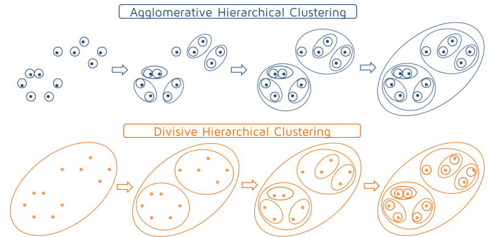

Source: https://quantdare.com/hierarchical-clustering/

## Preparing data:

### I. Data to cluster

**a.** Subset your data (recommended)

```r
selection=c("GEOID10","COMPOSITE_PERCENTILE", "RACE_ELL_ORIGINS_PERCENTILE","SOCIOECONOMIC_PERCENTILE","HEALTH_PERCENTILE")

dataToCluster=fromPy[,selection]
```

**b.** Set labels as row index

```r
dataToCluster$GEOID10=NULL
row.names(dataToCluster)=dataToCluster$GEOID10
```

**c.** Decide if data needs to be transformed:

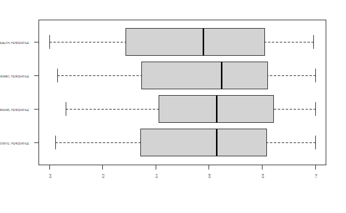

```r
boxplot(dataToCluster,horizontal = T, las=2,cex.axis=0.4)
```

### II. Compute the DISTANCE MATRIX:

**d.** Set random seed:

```r
set.seed(999) # this is for replicability of results
```

**e.** Decide distance method and compute distance matrix:

```r
library(cluster)
dataToCluster_DM=daisy(x=dataToCluster, metric = "gower")
```

## Compute Clusters

### 1. Apply function: you need to indicate a priori the amount of clusters required.

```r
NumberOfClusterDesired=4

# Partitioning technique
res.pam = pam(x=dataToCluster_DM,
              k = NumberOfClusterDesired,
              cluster.only = F)

# Hierarchical technique- agglomerative approach

library(factoextra)
res.agnes= hcut(dataToCluster_DM,
                k = NumberOfClusterDesired,
                isdiss=TRUE,
                hc_func='agnes',
                hc_method = "ward.D2")

# Hierarchical technique- divisive approach
res.diana= hcut(dataToCluster_DM,
                k = NumberOfClusterDesired,
                isdiss=TRUE,
                hc_func='diana',
                hc_method = "ward.D2")
```

### 2. Clustering results.

**2.1** Add results to original data frame:

```r
fromPy$pam=as.factor(res.pam$clustering)
fromPy$agn=as.factor(res.agnes$cluster)
fromPy$dia=as.factor(res.diana$cluster)
```

**2.2** Verify ordinality in clusters

```r
aggregate(data=fromPy,
          COMPOSITE_PERCENTILE~pam,
          FUN=mean)
```

| pam | COMPOSITE_PERCENTILE |
| --- | --- |
| 1 | 0.9087500 |
| 2 | 0.6861429 |
| 3 | 0.4104211 |
| 4 | 0.1395000 |

```r
aggregate(data=fromPy,
          COMPOSITE_PERCENTILE~agn,
          FUN=mean)
```

| agn | COMPOSITE_PERCENTILE |
| --- | --- |
| 1 | 0.9030952 |
| 2 | 0.6863158 |
| 3 | 0.4188500 |
| 4 | 0.1395000 |

```r
aggregate(data=fromPy,
          COMPOSITE_PERCENTILE~dia,
          FUN=mean)
```

| dia | COMPOSITE_PERCENTILE |
| --- | --- |
| 1 | 0.8965909 |
| 2 | 0.6767895 |
| 3 | 0.4173333 |
| 4 | 0.1507692 |

You could recode these values like this:

```r
library(dplyr)

fromPy$pam=dplyr::recode_factor(fromPy$pam,
                  `1` = '5',`2`='4',`3`='3',`4`='2',`5`='1')
fromPy$agn=dplyr::recode_factor(fromPy$agn,
                  `1` = '5',`2`='4',`3`='3',`4`='2',`5`='1')
fromPy$dia=dplyr::recode_factor(fromPy$dia,
                  `1` = '5',`2`='4',`3`='3',`4`='2',`5`='1')
```

### 3. Evaluate Results.

**3.1** Plot silhouettes

|  | cluster | size | ave.sil.width |
| --- | --- | --- | --- |
| 1 | 1 | 20 | 0.59 |
| 2 | 2 | 21 | 0.30 |
| 3 | 3 | 19 | 0.25 |
| 4 | 4 | 12 | 0.63 |

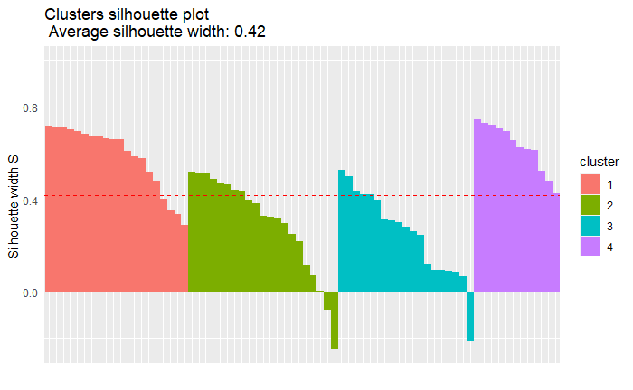

```r
# from factoextra
fviz_silhouette(res.pam)
```

|  | cluster | size | ave.sil.width |
| --- | --- | --- | --- |
| 1 | 1 | 21 | 0.56 |
| 2 | 2 | 19 | 0.34 |
| 3 | 3 | 20 | 0.23 |
| 4 | 4 | 12 | 0.64 |

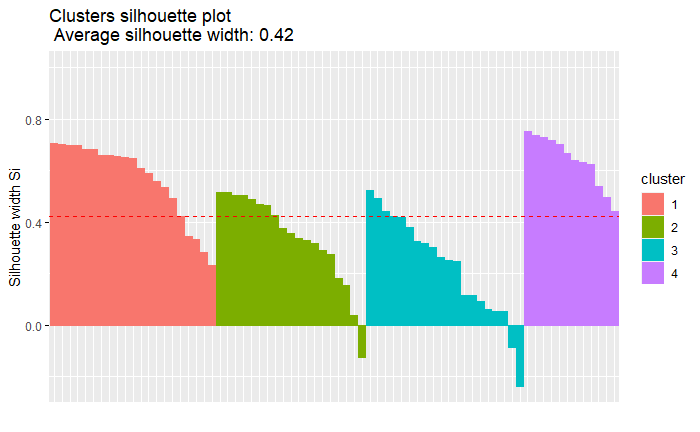

```r
fviz_silhouette(res.agnes)
```

|  | cluster | size | ave.sil.width |
| --- | --- | --- | --- |
| 1 | 1 | 22 | 0.54 |
| 2 | 2 | 19 | 0.35 |
| 3 | 3 | 18 | 0.25 |
| 4 | 4 | 13 | 0.60 |

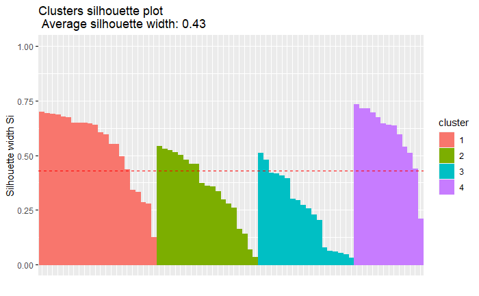

```r
library(factoextra)
library(ggplot2)
fviz_silhouette(res.diana)
```

**3.2** Detecting cases badly clustered

1. Save individual silhouettes:

Previos results have saved important information:

```r
head(data.frame(res.pam$silinfo$widths),20)
```

|  | cluster | neighbor | sil_width |
| --- | --- | --- | --- |
| 67 | 1 | 2 | 0.7147043 |
| 66 | 1 | 2 | 0.7126661 |
| 72 | 1 | 2 | 0.7102040 |
| 71 | 1 | 2 | 0.7049075 |
| 70 | 1 | 2 | 0.6967728 |
| 69 | 1 | 2 | 0.6849238 |
| 51 | 1 | 2 | 0.6734402 |
| 64 | 1 | 2 | 0.6708041 |
| 68 | 1 | 2 | 0.6644911 |
| 65 | 1 | 2 | 0.6601196 |

[output cut: 10 more lines]

```r
pamEval=data.frame(res.pam$silinfo$widths)
agnEval=data.frame(res.agnes$silinfo$widths)
diaEval=data.frame(res.diana$silinfo$widths)

pamPoor=rownames(pamEval[pamEval$sil_width<0,])
agnPoor=rownames(agnEval[agnEval$sil_width<0,])
diaPoor=rownames(diaEval[diaEval$sil_width<0,])
```

## Deliver II only up to here

# How to compare clustering?

- Prepare a bidimensional map using distances:

```r
projectedData = cmdscale(dataToCluster_DM, k=2)
#
# save coordinates to original data frame:
fromPy$dim1 = projectedData[,1]
fromPy$dim2 = projectedData[,2]
```

- See the “map”:

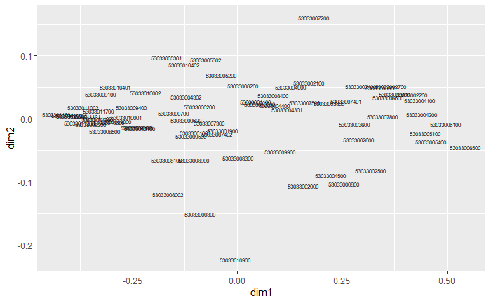

```r
base= ggplot(data=fromPy,
             aes(x=dim1, y=dim2,
                 label=GEOID10))
base + geom_text(size=2)
```

- Plot results from PAM:

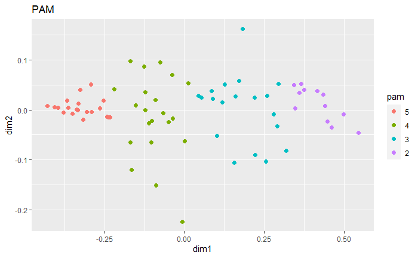

```r
pamPlot=base + labs(title = "PAM") + geom_point(size=2,
                                              aes(color=pam),
                                              show.legend = T)
pamPlot
```

- Plot results from Hierarchical AGNES:

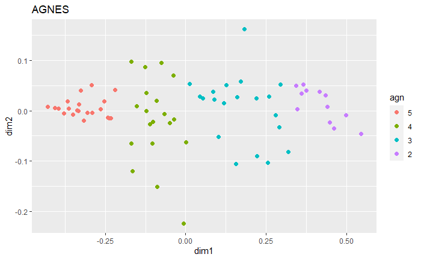

```r
agnPlot=base + labs(title = "AGNES") + geom_point(size=2,
                                              aes(color=agn),
                                              show.legend = T)
agnPlot
```

- Plot results from Hierarchical DIANA:

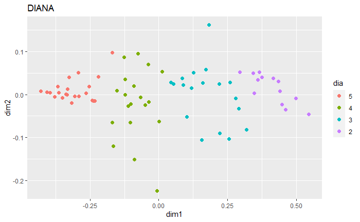

```r
diaPlot=base + labs(title = "DIANA") + geom_point(size=2,
                                              aes(color=dia),
                                              show.legend = T)
diaPlot
```

Compare visually:

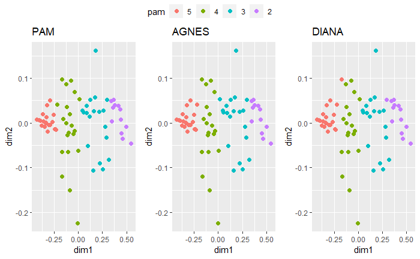

```r
library(ggpubr)

ggarrange(pamPlot, agnPlot, diaPlot,ncol = 3,common.legend = T)
```

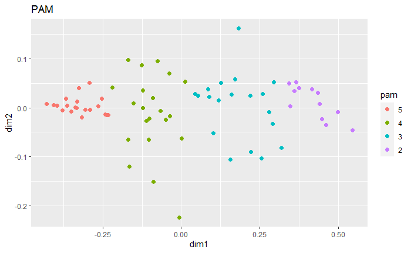

```r
library(ggrepel)
LABELpam=ifelse(fromPy$GEOID10%in%pamPoor,fromPy$GEOID10,"")
LABELdia=ifelse(fromPy$GEOID10%in%diaPoor,fromPy$GEOID10,"")
LABELagn=ifelse(fromPy$GEOID10%in%agnPoor,fromPy$GEOID10,"")
pamPlot + geom_text_repel(aes(label=LABELpam))
```

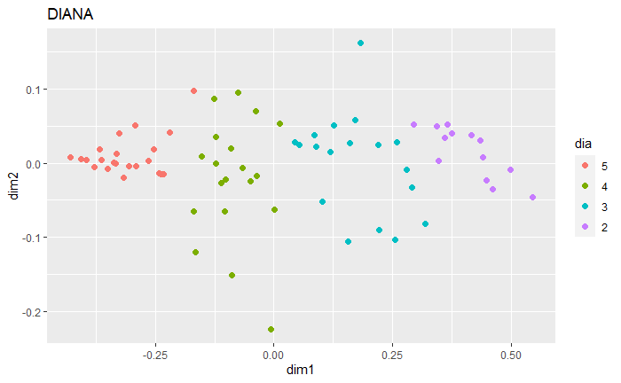

```r
diaPlot + geom_text_repel(aes(label=LABELdia))
```

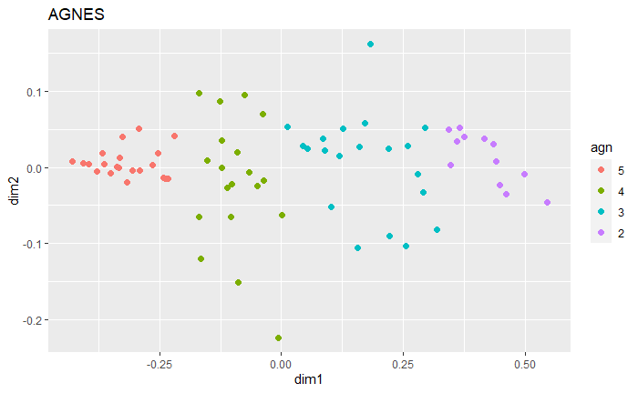

```r
agnPlot + geom_text_repel(aes(label=LABELagn))
```

- The Dendogram (for hierarchical approaches)

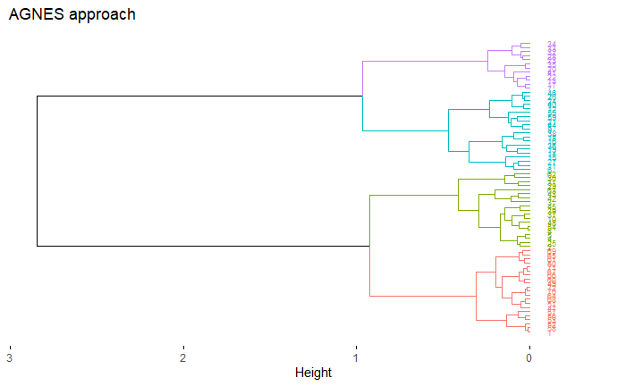

```r
fviz_dend(res.agnes,k=NumberOfClusterDesired, cex = 0.45, horiz = T,main = "AGNES approach")
```

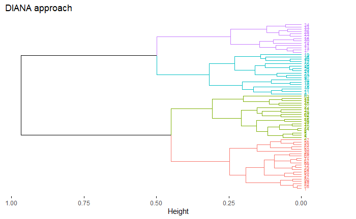

```r
fviz_dend(res.diana,k=NumberOfClusterDesired, cex = 0.45, horiz = T,main = "DIANA approach")
```

# FACTOR ANALYSIS

Simply speaking, this technique tries to express in one (or few) dimension(s) the behavior of several others. FA assumes that the several input variables have ‘something’ in common, there is something **latent** that the set of input variables represent.

```r
names(dataForFA)
```

```
[1] "GEOID10"                     "COMPOSITE_PERCENTILE"        "RACE_ELL_ORIGINS_PERCENTILE" "SOCIOECONOMIC_PERCENTILE"    "HEALTH_PERCENTILE"
```

```r
indexCFA=lavPredict(fit)
```

The index computed is not in a range from 0 to 10:

```r
indexCFA[1:10]
```

```
 [1]  0.65953108  0.53303532 -1.04044312  0.26763589  0.58399498 -2.05940252 -0.78674639  0.14523260  0.11944728 -0.02523516
```

We force its return to “0 to 10”:

```r
library(scales)
indexCFANorm=rescale(as.vector(indexCFA),
                     to = c(0, 10))
indexCFANorm[1:10]
```

```
 [1] 7.6428026 7.3156079 3.2456398 6.6291243 7.4474204 0.6099938 3.9018532 6.3125153 6.2458188 5.8715824
```

So, this is our index:

```r
fromPy$demo_FA=indexCFANorm
```

Let me compare the new index with the original score:

[figure not shown]

```r
evalCFA1=parameterEstimates(fit, standardized =TRUE)
```

- Loadings

```r
evalCFA1[evalCFA1$op=="=~",c('rhs','std.all','pvalue')]
```

|  | rhs | std.all | pvalue |
| --- | --- | --- | --- |
| 1 | RACE_ELL_ORIGINS_PERCENTILE | 0.788 | 0 |
| 2 | SOCIOECONOMIC_PERCENTILE | 1.003 | 0 |
| 3 | HEALTH_PERCENTILE | 0.877 | 0 |

- Some coefficients:

```r
evalCFA2=as.list(fitMeasures(fit))
```

- You want p.value of Chi-Square greater than 0.05:

```r
evalCFA2[c("chisq", "df", "pvalue")]
```

```
$chisq
[1] 1.278977e-13

$df
[1] 0

$pvalue
[1] NA
```

- You want the Tucker-Lewis > 0.9:

```r
evalCFA2$tli # > 0.90
```

```
[1] 1
```

- You want RMSEA < 0.05:

```r
evalCFA2[c( 'rmsea.ci.lower','rmsea','rmsea.ci.upper')]
```

```
$rmsea.ci.lower
[1] 0

$rmsea
[1] 0

$rmsea.ci.upper
[1] 0
```

You can see how it looks:

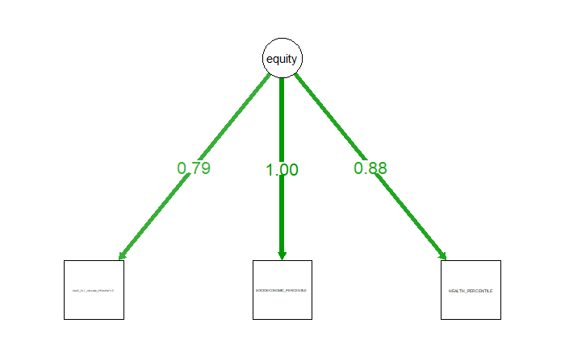

```r
library(semPlot)
semPaths(fit, what='std', nCharNodes=0, sizeMan=12,
         edge.label.cex=1.5, fade=T,residuals = F)
```